# QHCI 2021 - Project 2

Group 4

25.05.2021

This project is based on the paper *[How We Type: Movement Strategies and Performance in Everyday Typing](https://dl.acm.org/doi/10.1145/2858036.2858233)*. We used the data set the authors have provided within the course of their study. The aim of the data analysis will be to answer the following to research questions (*RQ*):

- *RQ1: Do overall typing speed differ between touch-typist and non-touchtypist?*
- *RQ2: How much does the result from RQ1 influenced by whether the participants type known-words or random string?*

The analysis will base on the **within-subject design** (with repeated trials) of the study including **one independent variable *(IV)*** that has **three levels**. The **IV *stimulus tpye*** refers to the type of string users had to type in for the transcription and has three levels:

- *sentences*: easy regular sentences
- *random*: random sequences of letters
- *mix*: a mix of the two other conditions

For the experiments they used a **randomized order** for the three *stimulus types*.

# Theoretical Background

The Feit (2006) paper compares typing of self-taught typists (or everyday typists or non-touch typists) to touch typists (those that took a typing course and are trained on ten-finger touch typing system). It does not seem to be the case that everyday typists are inferior in their typing skills/performance.

They conducted three types of tasks: easy sentences of commonly used words (sentences), random letter strings (random) and a mix of those two (mix). Thirty typists participated. They captured key press data (keyboard logging), motion capture data (the position of each finger at and between keystrokes) and eye tracking/attention data (with eye-tracking glasses). The experiment followed a within-subject design.

The paper does not find a significant difference in words-per-minute performance between touch typists (57.8 WPM) and non-touch typists (58.93 WPM). Touch typists and non-touch typists seem to have comparable speed. When typing random letter sequences the paper finds that entry rate dropped on average by around 50% compared to the sentences condition. The change was similar across both groups, with no significant difference between their performances in the random condition.

# Data Analysis

Within this part we will analyze the data set and try to answer the two research questions.

## Setup

Before we can jump into the analysis we start by installing the required packages.

```r
# define packages
packages <- c("tidyverse","lme4","multcomp","broom.mixed","lmerTest","ggplot2","plyr","lsm","lsmeans","car","stringr","PearsonDS", "ARTool", "qqplotr", "psych", "moments")

# install packages when they are not already included
install.packages(setdiff(packages, rownames(installed.packages())))
```

To finish the setup we need to load the packages fo finish the setup.

```r
# load the packages
library(tidyverse)
library(lme4)
library(ggplot2)
library(broom.mixed)
library(lmerTest)
library(plyr)
library(lsm)
library(lsmeans)
library(car)
library(stringr)
import::from(moments, skewness)
import::from(MASS,mvrnorm)
import::from(broom.mixed,tidy)
import::from(multcomp, glht, mcp, adjusted)
import::from(PearsonDS, rpearson)
import::from(ARTool, art, artlm, art.con)
import::from(qqplotr, stat_qq_line, stat_qq_point, stat_qq_band)
import::from(psych, d.ci)
import::from(cowplot, plot_grid)
import::from(modelr, add_residuals, add_predictions)
import::from(car, leveneTest, sigmaHat)
```

## Data Processing

Next we can start with the data processing. First off, we define a helper function `read_log_files` that will help read in all the different log files.

```r
# Regular expression to help parse the log files
regex_parse <- "User([\\d]*)_[^_]*_([^\\.]*)\\.csv"
# helper function to read in log files
readLog <- function(fileName) {
  csv_data <- read_csv(str_c('./log/', fileName))
  userId <- as.double(str_replace(fileName, regex_parse, "\\1"))
  logData <-
    csv_data %>%
    mutate(
      length = str_length(csv_data$stimulus),
      user_id = userId,
      condition = str_replace(fileName, regex_parse, "\\2"),
      typing_style = if_else(isTouchTypist(userId), "Non-touchtypist", "Touchtypist")
    ) %>%
    group_by(stimulus_index) %>%
    filter(input_time_ms == max(input_time_ms)) %>%
    mutate(wpm = ((length - 1) / 5) / input_time_ms * 60000) %>%
    select(c(stimulus_index, wpm, user_id, condition, typing_style))
  return(logData)
}
```

Thereafter, we define all the existing log files (`log_files`) and and the csv containing the participant information (`participant_info`).

```r
# list of all log files
log_files <- list.files('./log')
# file that includes the participant information
participant_info <- read_csv("participant_info.csv")
isTouchTypist <- function(userId) {
  s <- participant_info %>% filter(user_id == userId) %>% slice(1)
  return(s$is_touchtypist)
}
# backup file that is already processed
# combined_log_background <- read_csv(("combined_log_background.csv"))
```

Now we are ready to process the log files and create the data we need.

```r
# data wrangling
data <- tribble(~ user_id,  ~ wpm, ~ condition, ~ typing_style, ~ stimulus_index)
for (file in log_files) {
  data <- data %>% add_row(readLog(file))
}
# ? TODO add comment
data    <- data    %>% mutate(typing_style = factor(typing_style, levels = c("Touchtypist", "Non-touchtypist")))
```

> Note that the *IV stimulus type* is now referred to as *condition* in our data set with the same three levels (*Sentences, Random, Mix*). The *typing style* will still be referred to as *typing style*.

## Data Exploration and Description

After having processed the data, we now want to inspect and explore it to get a better overview. To do so we can describe its basic properties.

### General Information

Thus, it is a good idea to have a quick look at the data by using `head(data)`.

| user_id | wpm | condition | typing_style | stimulus_index |
| --- | --- | --- | --- | --- |
| 106194 | 34.83089 | Sentences | Touchtypist | 0 |
| 106194 | 48.59939 | Sentences | Touchtypist | 1 |
| 106194 | 48.87551 | Sentences | Touchtypist | 2 |
| 106194 | 75.51622 | Sentences | Touchtypist | 3 |
| 106194 | 54.03974 | Sentences | Touchtypist | 4 |
| 106194 | 43.79562 | Sentences | Touchtypist | 5 |

Next we check the structure of the data object with `str(data)` and can see the data types of each column.

```
## tibble [4,509 x 5] (S3: tbl_df/tbl/data.frame)
##  $ user_id       : num [1:4509] 106194 106194 106194 106194 106194 ...
##  $ wpm           : num [1:4509] 34.8 48.6 48.9 75.5 54 ...
##  $ condition     : chr [1:4509] "Sentences" "Sentences" "Sentences" "Sentences" ...
##  $ typing_style  : Factor w/ 2 levels "Touchtypist",..: 1 1 1 1 1 1 1 1 1 1 ...
##  $ stimulus_index: num [1:4509] 0 1 2 3 4 5 6 7 8 9 ...
```

Out data set contains 5 columns (*user_id, wpm, condition, typing_style, stimulus_index*) and 4509 rows for 30 different users.

### Descriptive Statisctics

Now that we know how the data looks and what type of data it contains, we can have a look at the data itself. To get a broad overview of the data we use the `summary` function.

```
##     user_id            wpm           condition                  typing_style
##  Min.   :  5307   Min.   :  6.389   Length:4509        Touchtypist    :2399
##  1st Qu.:221357   1st Qu.: 29.217   Class :character   Non-touchtypist:2110
##  Median :376930   Median : 40.632   Mode  :character
##  Mean   :399563   Mean   : 43.477
##  3rd Qu.:535385   3rd Qu.: 56.227
##  Max.   :934313   Max.   :109.331
##  stimulus_index
##  Min.   : 0.0
##  1st Qu.:12.0
##  Median :24.0
##  Mean   :24.5
##  3rd Qu.:37.0
##  Max.   :49.0
```

In order to answer the research questions we will now have a look at the *words per minute (wpm)* first with regards to the *typing style* (RQ1) and then in connection with the different *conditions* (RQ2). To support this process we will also create suitable visualizations for the data sets.

#### **RQ1 - words per minute (wpm) by typing styles**

First we create a violin plot that includes boxplots for *words per minute (wpm)* by the *typing styles* of users.

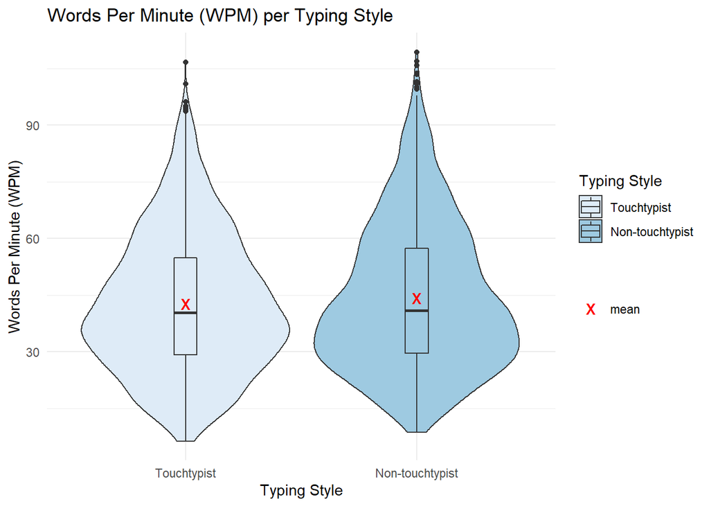

Out of this first visualization, we can already imply that there is no big difference between the two *typing styles* with regards to *words per minutes (wpm)*. This is also shown in the numbers.

Skewness is a commonly used measure of the symmetry of a statistical distribution. A negative skewness indicates that the distribution is left skewed and the mean of the data (average) is less than the median value

**Non-Parametric Statisctics**

- Median:
  - On the one hand Touchtypist has a `median` of 40.368272 *wpms* and on the other hand Non-touchtypist has a `median` of 40.9242053 *wpms*.
- Min and Max Values:
  - For the `min` values Touchtypist has a value of 6.3890959 *wpms* and Non-touchtypist has a value of 8.7412587 *wpms*.
  - Regarding the `max`values Touchtypist has a value of 106.5614208 *wpms* and Non-touchtypist has a value of 109.33082 *wpms*.
- Interquartile Range (IQR) :
  - The `IQR` of Touchtypist amounts to 25.8003127 and on the `IQR` for Non-touchtypist to 27.7820302.

These non-parametric statistical properties confirm the initial impressions from the visualization above that there are only slight differences between the two *typing styles* with regards to *words per minute (wpm)*. The `median`, `min`, `max`, as well as the `IQR` reveal only small differences.

**Parametric Statistics**

- Mean:
  - On the one hand Touchtypist has a `mean` of 42.7261771 *wpms* and on the other hand Non-touchtypist has a `mean` of 44.3316907 *wpms*.
- Spread:
  - For the variance (`var`), Touchtypist has a value of 339.5129545 and Non-touchtypist has a value of 374.4727546.
  - Regarding the standard deviation, (`sd`) Touchtypist accounts to 18.4258773 and Non-touchtypist to 19.3512985.

These numbers shows that also the parametric statistical properties in the form of `mean`, variance(`var`) and standard deviation(`sd`) are quite similar.

Now that we have concrete numbers for both the `mean` and the `median` for *typing styles* by *wpms* we can make a statement about the distributions of the data and their shapes. For Touchtypist that have a `mean` of 42.7261771 *wpms* and a `median` of 40.368272 *wpms*, the shape is skewed right. The same applies For Non-touchtypist that have a `mean` of 44.3316907 *wpms* and a `median` of 40.9242053 *wpms*, where the shape is skewed-right.

Eventually, the numbers confirmed the initial impressions from the visualizations that there is not a big difference between the two *typing styles* with regards to the *wpms*. But there is a slight difference for example in the distribution and shape of the data.

#### Histograms

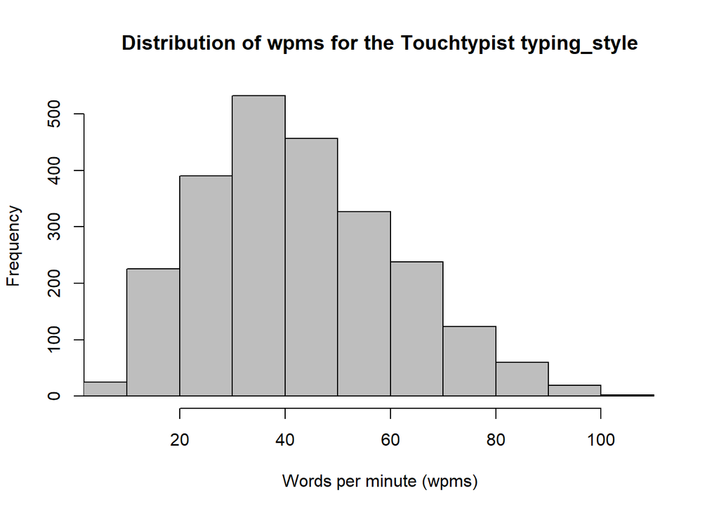

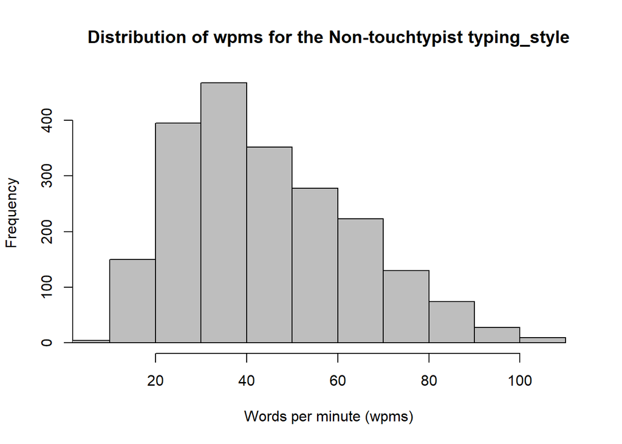

```r
# r function for skewness
by(data = data$wpm, INDICES = data$typing_style, FUN = skewness)
```

```
## data$typing_style: Touchtypist
## [1] 0.4666713
## ------------------------------------------------------------
## data$typing_style: Non-touchtypist
## [1] 0.6164875
```

#### **RQ2 - words per minute (wpm) by typing style and condition (stimulus type)**

We begin by taking a look at condition on its own. We create the same plot again for *words per minute (wpm)* by the different *conditions*.

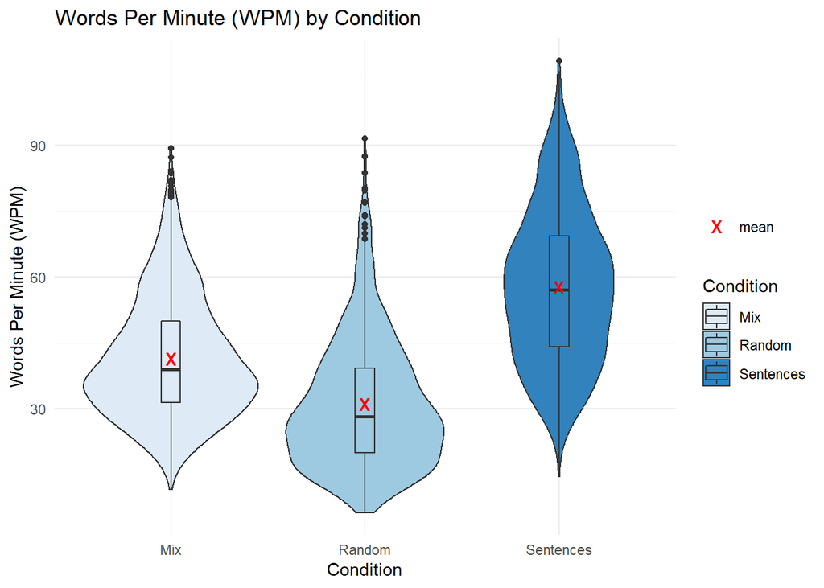

In contrast to the visualization before, in this case we immediately see that the violin and boxplots appear quite different with regards to the *conditions* and *word per minutes (wpm)*. We see that random characters/words seem to lead to the lowest WPM performance, while known sentences show the highest WPM performance. The mix condition, as to be expected, lies between the two conditions, random and sentences. Next, we can take a look at the numbers.

**Non-Parametric Statistics**

- Median:
  - Mix has a `median` of 38.9025636 *wpms*, Random has a `median` of 28.2885431 *wpms* and Sentences has a `median` of 57.167605 *wpms*.
- Min and Max Values:
  - For the `min` values Mix has a value of 11.6360502 *wpms*, Random has a value of 6.3890959 *wpms* and Sentences has a value of 14.5406477 *wpms*.
  - Regarding the `max`values Mix has a value of 89.2789012 *wpms*, Random has a value of 91.6030534 *wpms* and Sentences has a value of 109.33082 *wpms*.
- Interquartile Range (IQR) :
  - The `IQR` of Mix amounts to 18.4996696, the `IQR` for Random to 19.2403134 and on the `IQR` for Sentences to 25.3134159.

The `median`, `min`, `max`, as well as the `IQR` this time show significant differences that are also obvious in the visualizations. Upon these we can already make a statement about RQ2.

At this point we can already say that there are obvious differences between the *conditions*.

**Parametric Statistics**

- Mean:
  - For the Mix users have a `mean` of 41.5235543 *wpms*, forRandom a `mean` of 31.0927423 *wpms* and forSentences has a `mean` of 57.7421369 *wpms*.
- Spread:
  - For the variance (`var`), Mix has a value of 188.4205488, Random has a value of 217.1712564 and Sentences has a value of 303.3515591.
  - Regarding the standard deviation, (`sd`) Mix accounts to 13.7266365, Random to 14.7367315 and Sentences to 17.4169905.

Looking at the concrete numbers for both the `mean` and the `median` for *condtitions* by *wpms* this gets clearer:

- Condition Mix:
  - For Mix that have a `mean` of 41.5235543 *wpms* and a `median` of 38.9025636 *wpms*.
- Condition Random:
  - The same applies for Random with a `mean` of 31.0927423 *wpms* and a `median` of 28.2885431 *wpms*.
- Condition Sentences:
  - For Sentences the `mean` is 57.7421369 *wpms* and the `median` is 57.167605 *wpms*.

Eventually, for this case the the numbers related to the spread of the data (variance(`var`), standard deviation(`sd`), `IQR`) do confirm the impression of the visualization that there are significant differences. The `mean` and `median` do not show big differences at all for all three conditions.

#### Histograms

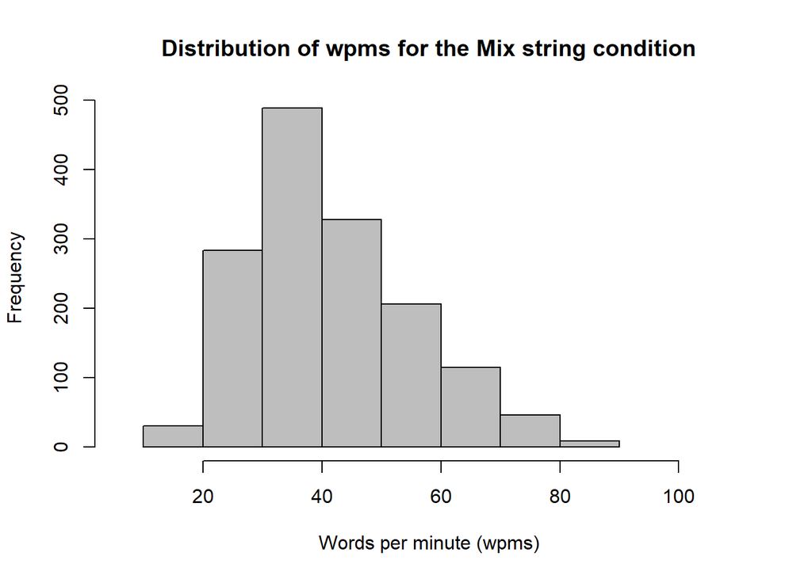

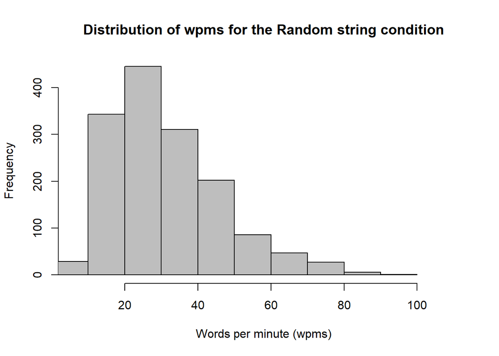

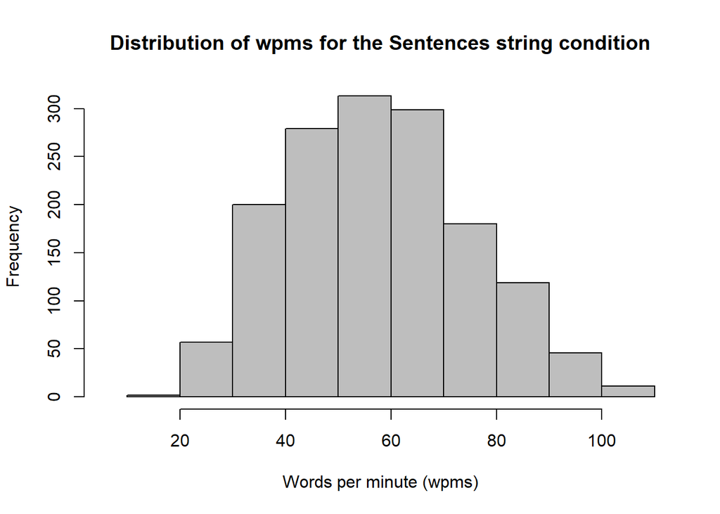

After looking at *condition* on its own, we turn to the interaction of typing style and condition. We create the violin plot for *words per minute (wpm)* by the different *typing styles* and *conditions*. We find that even across conditions there do not seem to be significant differences between non-touchtypists and touchtypists in WPM. These findings all seem to back the Feit (2006) paper.

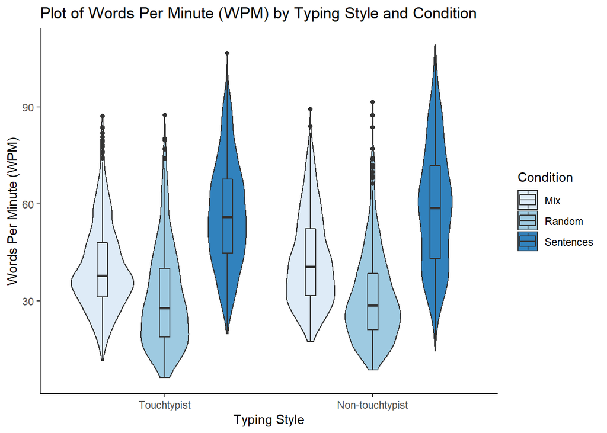

| typing_style | condition | Min. | 1st Qu. | Median | Mean | 3rd Qu. | Max. |
| --- | --- | --- | --- | --- | --- | --- | --- |
| Touchtypist | Mix | 11.636050 | 31.27961 | 37.86042 | 40.35524 | 48.07993 | 87.17949 |
| Touchtypist | Random | 6.389096 | 18.86199 | 27.86809 | 30.90683 | 40.08016 | 87.46356 |
| Touchtypist | Sentences | 19.799646 | 44.81095 | 56.02241 | 56.86924 | 67.65328 | 106.56142 |
| Non-touchtypist | Mix | 17.454545 | 31.66304 | 40.62448 | 42.84743 | 52.34212 | 89.27890 |
| Non-touchtypist | Random | 8.741259 | 21.14165 | 28.69440 | 31.30499 | 38.48621 | 91.60305 |
| Non-touchtypist | Sentences | 14.540648 | 43.19372 | 58.75807 | 58.73390 | 71.94995 | 109.33082 |

We can also take a look at the typing style * condition distributions with the help of histogram plots.

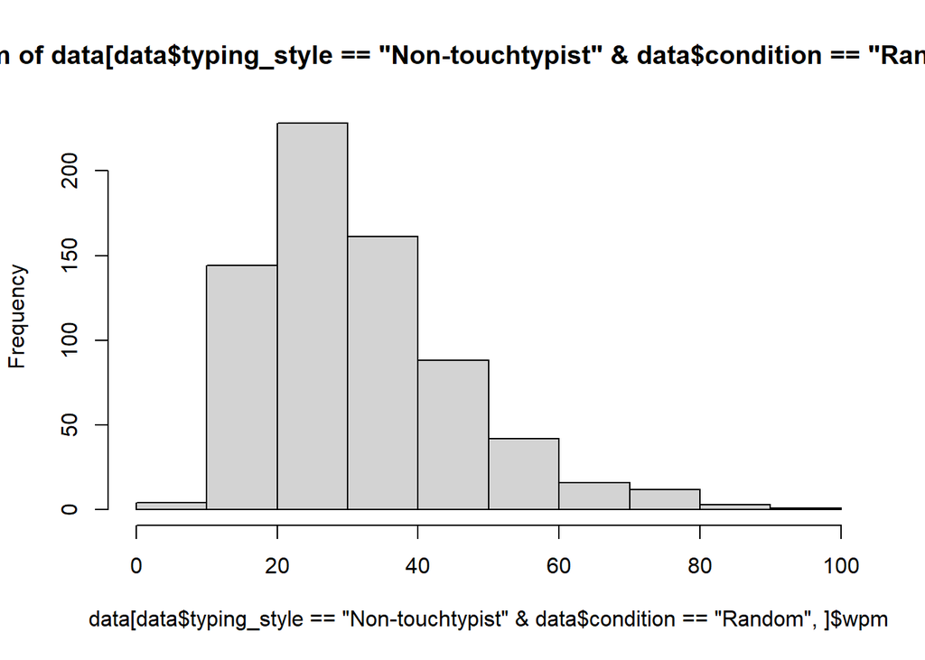

```r
hist(data[data$typing_style=='Non-touchtypist' & data$condition=='Random',]$wpm)
```

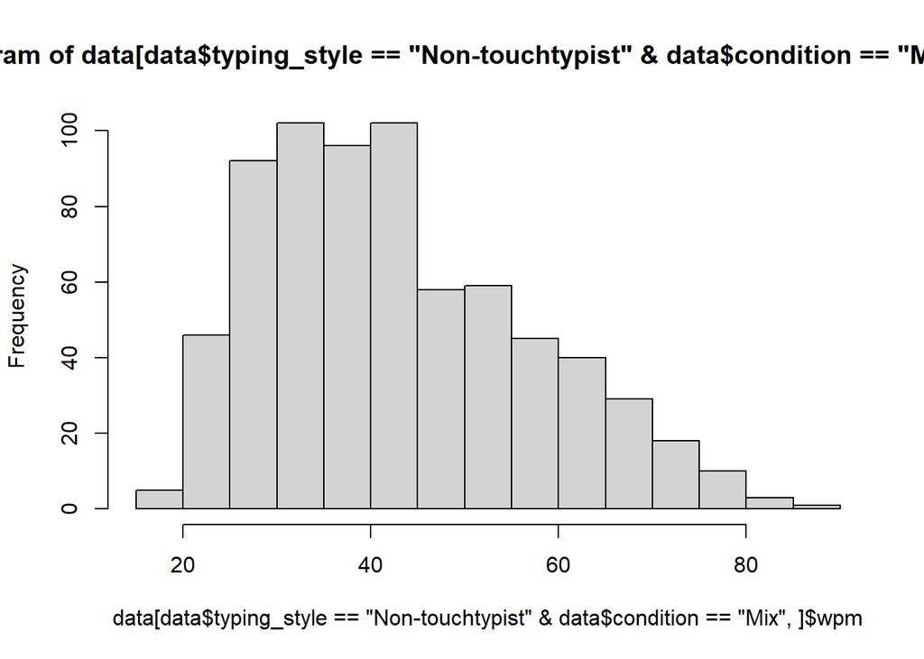

```r
hist(data[data$typing_style=='Non-touchtypist' & data$condition=='Mix',]$wpm)
```

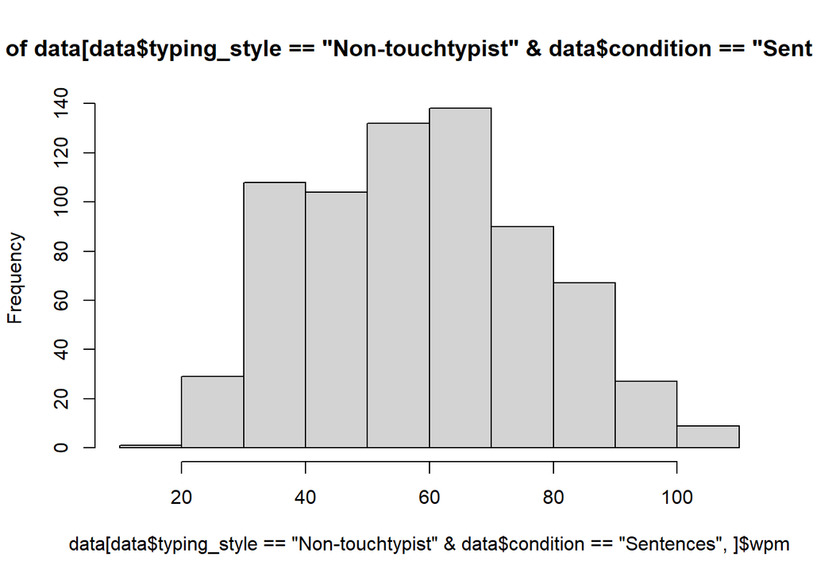

```r
hist(data[data$typing_style=='Non-touchtypist' & data$condition=='Sentences',]$wpm)
```

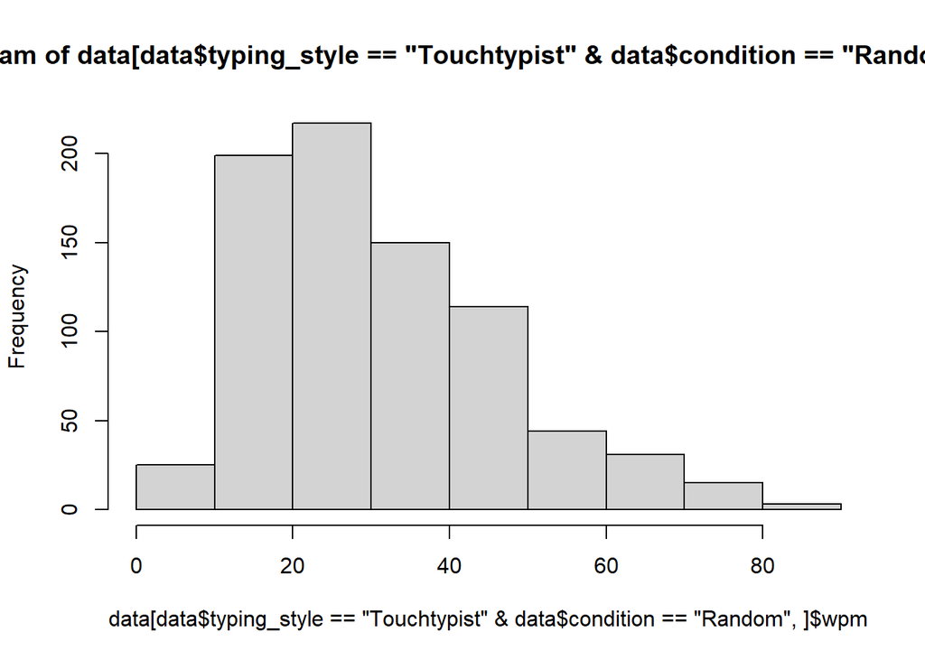

```r
hist(data[data$typing_style=='Touchtypist' & data$condition=='Random',]$wpm)
```

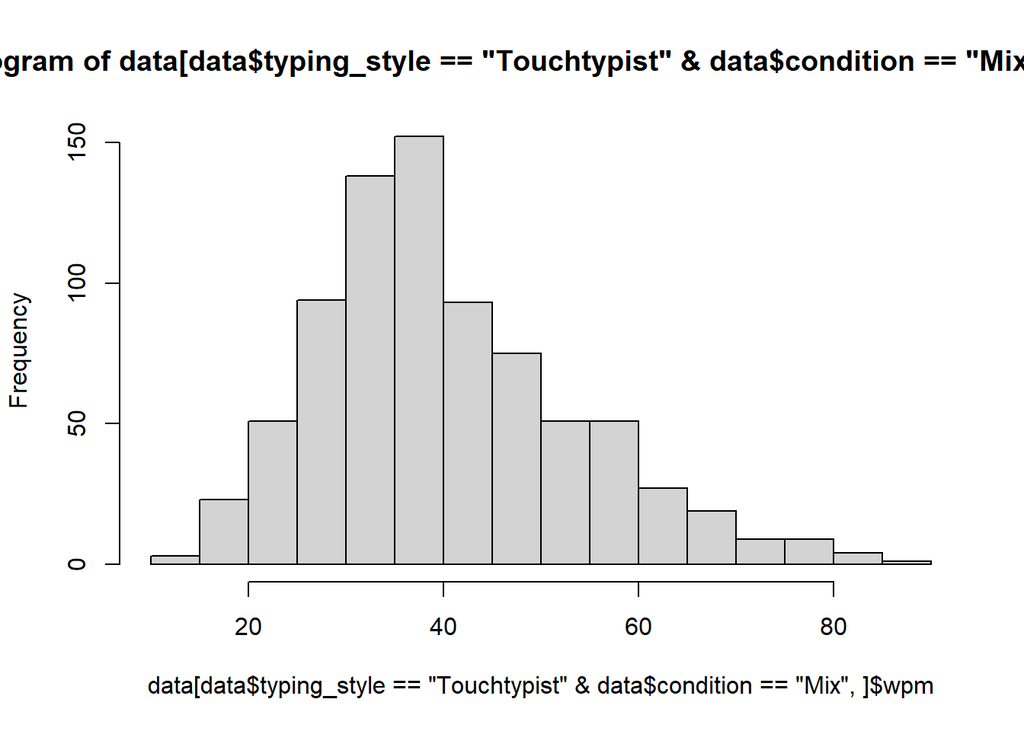

```r
hist(data[data$typing_style=='Touchtypist' & data$condition=='Mix',]$wpm)
```

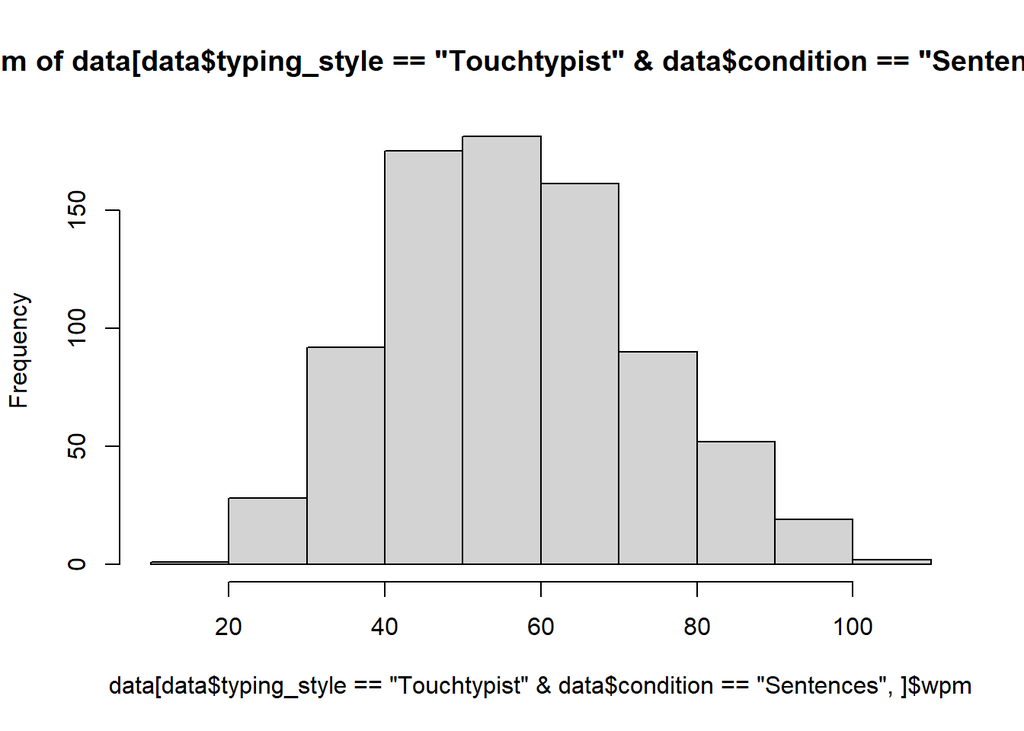

```r
hist(data[data$typing_style=='Touchtypist' & data$condition=='Sentences',]$wpm)
```

We can also take a look at the typing style * condition boxplot.

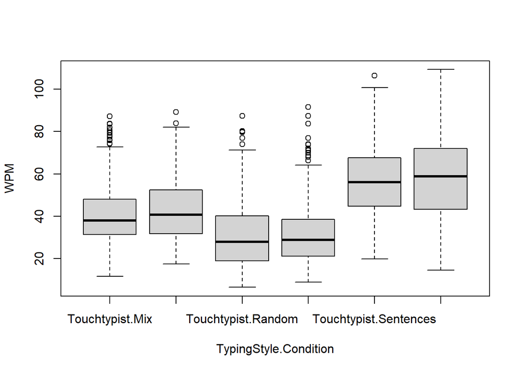

```r
boxplot(wpm ~ typing_style*condition,data=data,xlab='TypingStyle.Condition',ylab='WPM')
```

Finally, we can create a line plot.

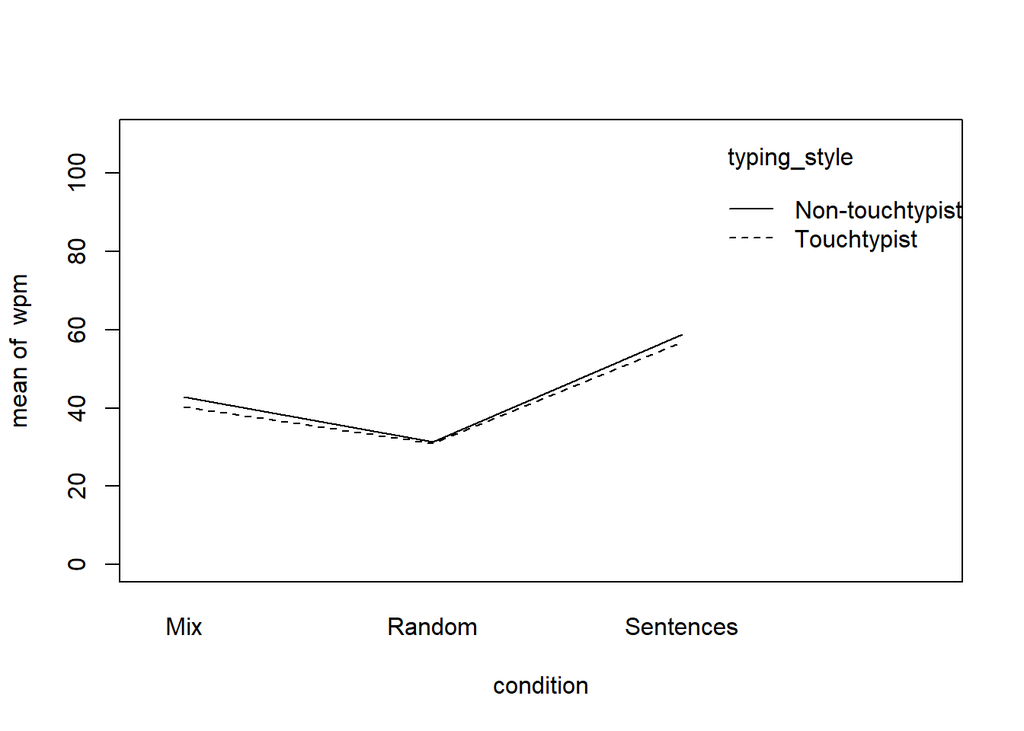

```r
with(data,interaction.plot(condition,typing_style,wpm,ylim=c(0,max(data$wpm))))
```

Both the boxplot and the line plot corroborate our findings.

## Modelling and Testing Assumptions

### Modelling

After exploring and visualizing the data, we can first set up our model and then take a look at it. We will set up a linear mixed model. In our case, we have multiple users. The variable typing_style is a between subjects variable and the variable condition is a within subjects variable. Furthermore we have multiple trials, whereby the variable is called stimulus_index. We are trying to predict words per minute. As a quick note: Mixed models have much larger degrees of freedom.

```r
model <- lmer(wpm ~ (typing_style*condition)/stimulus_index+(1|user_id),data=data)
```

What we find in the model, is that the effect on typing style is not significant and neither is the effect on the interaction term typing style * condition. The condition itself however does show a significant effect.

```r
anova(model,type=3,test.statistic="F")
```

|  | Sum Sq | Mean Sq | NumDF | DenDF | F value | Pr(>F) |
| --- | --- | --- | --- | --- | --- | --- |
| typing_style | 32.40782 | 32.40782 | 1 | 29.26986 | 0.2469078 | 6.229727e-01 |
| condition | 133067.63483 | 66533.81742 | 2 | 4469.00217 | 506.9060379 | 3.908580e-199 |
| typing_style:condition | 130.70144 | 65.35072 | 2 | 4469.00217 | 0.4978923 | 6.078441e-01 |
| typing_style:condition:stimulus_index | 1620.80918 | 270.13486 | 6 | 4469.00212 | 2.0580961 | 5.485815e-02 |

We can create a model summary.

```r
summary(model)
```

```
## Linear mixed model fit by REML. t-tests use Satterthwaite's method [
## lmerModLmerTest]
## Formula: wpm ~ (typing_style * condition)/stimulus_index + (1 | user_id)
##    Data: data
##
## REML criterion at convergence: 34941.9
##
## Scaled residuals:
##     Min      1Q  Median      3Q     Max
## -3.6090 -0.6636 -0.0455  0.6253  3.8495
##
## Random effects:
##  Groups   Name        Variance Std.Dev.
##  user_id  (Intercept) 111.3    10.55
##  Residual             131.3    11.46
## Number of obs: 4509, groups:  user_id, 30
##
## Fixed effects:
##                                                                 Estimate
## (Intercept)                                                    3.983e+01
## typing_styleNon-touchtypist                                    2.691e+00
## conditionRandom                                               -7.690e+00
## conditionSentences                                             1.756e+01
## typing_styleNon-touchtypist:conditionRandom                   -1.629e+00
## typing_styleNon-touchtypist:conditionSentences                -5.997e-01
## typing_styleTouchtypist:conditionMix:stimulus_index            2.197e-02
## typing_styleNon-touchtypist:conditionMix:stimulus_index        8.793e-03
## typing_styleTouchtypist:conditionRandom:stimulus_index        -5.103e-02
## typing_styleNon-touchtypist:conditionRandom:stimulus_index    -7.702e-02
## typing_styleTouchtypist:conditionSentences:stimulus_index     -2.150e-02
## typing_styleNon-touchtypist:conditionSentences:stimulus_index -3.263e-02
##                                                               Std. Error
## (Intercept)                                                    2.756e+00
## typing_styleNon-touchtypist                                    4.034e+00
## conditionRandom                                                1.129e+00
## conditionSentences                                             1.129e+00
## typing_styleNon-touchtypist:conditionRandom                    1.651e+00
## typing_styleNon-touchtypist:conditionSentences                 1.649e+00
## typing_styleTouchtypist:conditionMix:stimulus_index            2.807e-02
## typing_styleNon-touchtypist:conditionMix:stimulus_index        2.987e-02
```

[output cut: 56 more lines]

[output not shown]

We can also check out the confidence intervals.

```r
confint(model)
```

```
## Computing profile confidence intervals ...
```

```
##                                                                     2.5 %
## .sig01                                                         8.04919191
## .sigma                                                        11.21089599
## (Intercept)                                                   34.44942194
## typing_styleNon-touchtypist                                   -5.18166491
## conditionRandom                                               -9.90074002
## conditionSentences                                            15.34853006
## typing_styleNon-touchtypist:conditionRandom                   -4.86325386
## typing_styleNon-touchtypist:conditionSentences                -3.82773638
## typing_styleTouchtypist:conditionMix:stimulus_index           -0.03300188
## typing_styleNon-touchtypist:conditionMix:stimulus_index       -0.04969654
## typing_styleTouchtypist:conditionRandom:stimulus_index        -0.10599266
## typing_styleNon-touchtypist:conditionRandom:stimulus_index    -0.13587007
## typing_styleTouchtypist:conditionSentences:stimulus_index     -0.07637599
## typing_styleNon-touchtypist:conditionSentences:stimulus_index -0.09120433
##                                                                     97.5 %
## .sig01                                                        13.457204884
## .sigma                                                        11.684983427
## (Intercept)                                                   45.206356121
## typing_styleNon-touchtypist                                   10.562862016
## conditionRandom                                               -5.479177924
## conditionSentences                                            19.769729639
## typing_styleNon-touchtypist:conditionRandom                    1.604528779
## typing_styleNon-touchtypist:conditionSentences                 2.628440889
## typing_styleTouchtypist:conditionMix:stimulus_index            0.076943452
## typing_styleNon-touchtypist:conditionMix:stimulus_index        0.067284287
## typing_styleTouchtypist:conditionRandom:stimulus_index         0.003941533
## typing_styleNon-touchtypist:conditionRandom:stimulus_index    -0.018164563
## typing_styleTouchtypist:conditionSentences:stimulus_index      0.033385245
## typing_styleNon-touchtypist:conditionSentences:stimulus_index  0.025939698
```

The GLHT shows that there is no significant difference between touchtypists and non touchtypists.

```r
model %>%
  glht(mcp(typing_style = "Tukey")) %>%
  tidy(conf.int = TRUE)
```

| term | contrast | null.value | estimate | conf.low | conf.high | statistic | adj.p.value |
| --- | --- | --- | --- | --- | --- | --- | --- |
| typing_style | Non-touchtypist - Touchtypist | 0 | 2.69062 | -5.215262 | 10.5965 | 0.6670373 | 0.5047483 |

```r
model %>%
  glht(mcp(typing_style = "Tukey")) %>%
  summary(test = adjusted("holm")) %>%
  tidy()
```

| term | contrast | null.value | estimate | std.error | statistic | adj.p.value |
| --- | --- | --- | --- | --- | --- | --- |
| typing_style | Non-touchtypist - Touchtypist | 0 | 2.69062 | 4.033688 | 0.6670373 | 0.5047483 |

Not only do we find that there is no significant difference in WPM between non-touchtypists and touchtypists, we also find that this does not change when looking and random strings and sentences. Neither “Non-touchtypist Random” - “Touchtypist Random” == 0 nor “Non-touchtypist Sentences” - “Touchtypist Sentences” == 0 turn out to be significant.

```r
summary(glht(model,lsm(pairwise~typing_style*condition,pbkrtest.limit = 4493)))
```

[output not shown]

[output not shown]

```
## NOTE: Results may be misleading due to involvement in interactions
```

```
##
##   Simultaneous Tests for General Linear Hypotheses
##
## Fit: lmer(formula = wpm ~ (typing_style * condition)/stimulus_index +
##     (1 | user_id), data = data)
##
## Linear Hypotheses:
##                                                             Estimate Std. Error
## Touchtypist Mix - (Non-touchtypist Mix) == 0                 -2.3678     3.9063
## Touchtypist Mix - Touchtypist Random == 0                     9.4782     0.5732
## Touchtypist Mix - (Non-touchtypist Random) == 0               9.0536     3.9065
## Touchtypist Mix - Touchtypist Sentences == 0                -16.4943     0.5727
## Touchtypist Mix - (Non-touchtypist Sentences) == 0          -18.3124     3.9063
## (Non-touchtypist Mix) - Touchtypist Random == 0              11.8460     3.9063
## (Non-touchtypist Mix) - (Non-touchtypist Random) == 0        11.4214     0.6113
## (Non-touchtypist Mix) - Touchtypist Sentences == 0          -14.1265     3.9063
## (Non-touchtypist Mix) - (Non-touchtypist Sentences) == 0    -15.9447     0.6100
## Touchtypist Random - (Non-touchtypist Random) == 0           -0.4246     3.9066
## Touchtypist Random - Touchtypist Sentences == 0             -25.9725     0.5730
## Touchtypist Random - (Non-touchtypist Sentences) == 0       -27.7907     3.9064
## (Non-touchtypist Random) - Touchtypist Sentences == 0       -25.5479     3.9065
## (Non-touchtypist Random) - (Non-touchtypist Sentences) == 0 -27.3661     0.6115
## Touchtypist Sentences - (Non-touchtypist Sentences) == 0     -1.8182     3.9063
##                                                             z value Pr(>|z|)
## Touchtypist Mix - (Non-touchtypist Mix) == 0                 -0.606  0.98597
## Touchtypist Mix - Touchtypist Random == 0                    16.536  < 0.001
## Touchtypist Mix - (Non-touchtypist Random) == 0               2.318  0.13140
## Touchtypist Mix - Touchtypist Sentences == 0                -28.803  < 0.001
## Touchtypist Mix - (Non-touchtypist Sentences) == 0           -4.688  < 0.001
## (Non-touchtypist Mix) - Touchtypist Random == 0               3.033  0.01795
## (Non-touchtypist Mix) - (Non-touchtypist Random) == 0        18.683  < 0.001
## (Non-touchtypist Mix) - Touchtypist Sentences == 0           -3.616  0.00215
## (Non-touchtypist Mix) - (Non-touchtypist Sentences) == 0    -26.138  < 0.001
## Touchtypist Random - (Non-touchtypist Random) == 0           -0.109  1.00000
## Touchtypist Random - Touchtypist Sentences == 0             -45.326  < 0.001
## Touchtypist Random - (Non-touchtypist Sentences) == 0        -7.114  < 0.001
## (Non-touchtypist Random) - Touchtypist Sentences == 0        -6.540  < 0.001
## (Non-touchtypist Random) - (Non-touchtypist Sentences) == 0 -44.750  < 0.001
## Touchtypist Sentences - (Non-touchtypist Sentences) == 0     -0.465  0.99586
##
## Touchtypist Mix - (Non-touchtypist Mix) == 0
## Touchtypist Mix - Touchtypist Random == 0                   ***
## Touchtypist Mix - (Non-touchtypist Random) == 0
## Touchtypist Mix - Touchtypist Sentences == 0                ***
## Touchtypist Mix - (Non-touchtypist Sentences) == 0          ***
## (Non-touchtypist Mix) - Touchtypist Random == 0             *
## (Non-touchtypist Mix) - (Non-touchtypist Random) == 0       ***
## (Non-touchtypist Mix) - Touchtypist Sentences == 0          **
## (Non-touchtypist Mix) - (Non-touchtypist Sentences) == 0    ***
## Touchtypist Random - (Non-touchtypist Random) == 0
## Touchtypist Random - Touchtypist Sentences == 0             ***
## Touchtypist Random - (Non-touchtypist Sentences) == 0       ***
## (Non-touchtypist Random) - Touchtypist Sentences == 0       ***
## (Non-touchtypist Random) - (Non-touchtypist Sentences) == 0 ***
## Touchtypist Sentences - (Non-touchtypist Sentences) == 0
## ---
## Signif. codes:  0 '***' 0.001 '**' 0.01 '*' 0.05 '.' 0.1 ' ' 1
## (Adjusted p values reported -- single-step method)
```

### Testing Statistical Assumptions

To test statistical assumptions, we begin by adding the residuals and predictions and create the residual versus prediction plot. There seems to be a wide range in residuals.

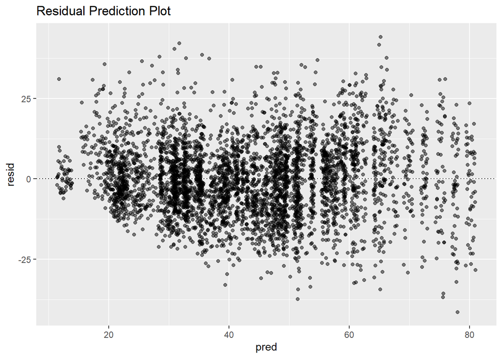

```r
data%>%
add_residuals(model)%>%
add_predictions(model)%>%
ggplot(aes(x = pred, y = resid)) +
geom_hline(yintercept = 0, linetype = "dotted") +
geom_point(alpha = 0.5) +
labs(title = "Residual Prediction Plot")
```

Next, we can create a QQ plot. There seem to be quite some points that are out of bounds.

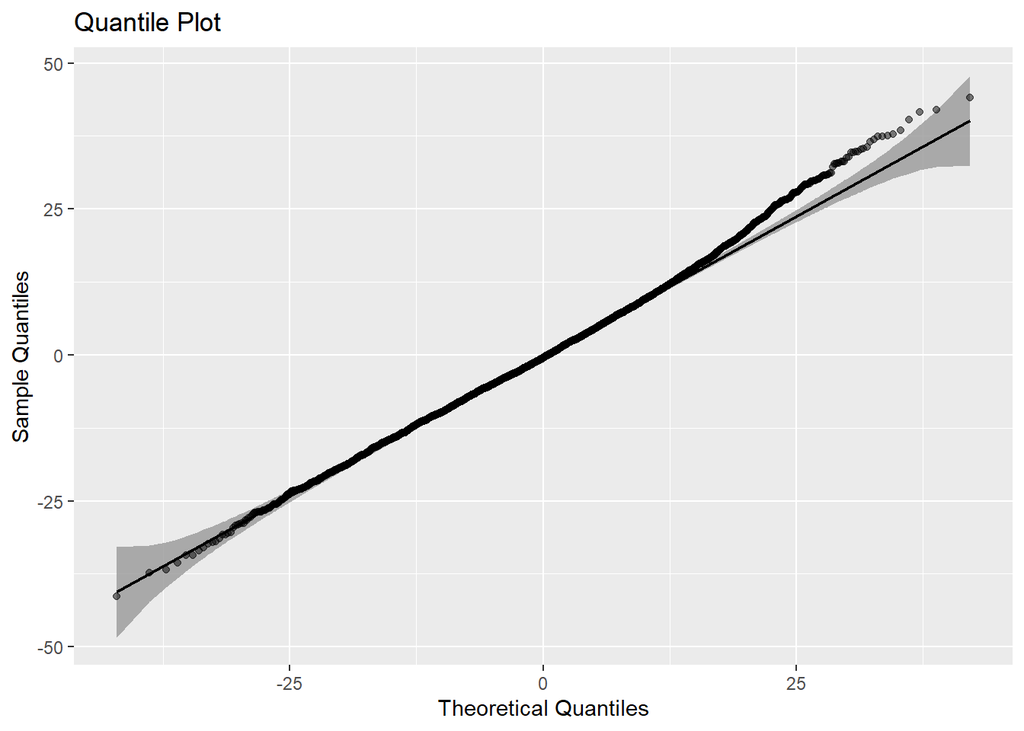

```r
data%>%
add_residuals(model)%>%
add_predictions(model)%>%
ggplot(aes(sample = resid)) +
stat_qq_band() +
stat_qq_line() +
stat_qq_point(alpha = 0.5) +
labs(x = "Theoretical Quantiles", y = "Sample Quantiles", title = "Quantile Plot")
```

Next we run a Shapiro test and a Levene test. We find that for the Shapiro test the p-value is extremely small and therefore the normality assumption is highly likely to be violated. For the Levene test we find that we do not reject the homoscedasticity assumption.

```r
shapiro.test(residuals(model))
```

```
##
##  Shapiro-Wilk normality test
##
## data:  residuals(model)
## W = 0.99608, p-value = 1.43e-09
```

```r
leveneTest(residuals(model) ~ data$typing_style, center = "median")
```

|  | Df | F value | Pr(>F) |
| --- | --- | --- | --- |
| group | 1 | 0.1705694 | 0.6796259 |
|  | 4507 | NA | NA |

### Model Transformation

Then we can do the log-transformation. We do this by taking the log of WPM.

```r
model_log <- lmer(log(wpm) ~ (typing_style*condition)/stimulus_index+(1|user_id),data=data)
```

### Re-Testing Statistical Assumptions

```r
shapiro.test(residuals(model_log))
```

```
##
##  Shapiro-Wilk normality test
##
## data:  residuals(model_log)
## W = 0.98972, p-value < 2.2e-16
```

Next we can run the GLHT.

```r
model_log %>%
  glht(mcp(typing_style = "Tukey")) %>%
  tidy(conf.int = TRUE) %>%
  mutate(
    conf.low = exp(conf.low),
    conf.high = exp(conf.high),
    estimate = exp(estimate))
```

| term | contrast | null.value | estimate | conf.low | conf.high | statistic | adj.p.value |
| --- | --- | --- | --- | --- | --- | --- | --- |
| typing_style | Non-touchtypist - Touchtypist | 0 | 1.061312 | 0.8781754 | 1.282641 | 0.6157363 | 0.5380686 |